# Installation

Jordan Richards

2023-11-12

Installing Keras and tensorflow for R can be quite tricky. Below are two options for using Keras during the practical aspect of the shortcourse:

1. Install a working version of Keras on your local machine; or
2. Use R and Keras from a Google Colab notebook.

# Installing Keras locally

To do so, update to the latest versions of R and Rstudio and run:

```r
    install.packages("remotes")
    remotes::install_github("rstudio/tensorflow")
    remotes::install_github("rstudio/keras")
    reticulate::install_miniconda(force=T)
    tf_version="2.11.0"

    tensorflow::install_tensorflow(version = tf_version)
    keras::install_keras()

    keras::is_keras_available() #Check if keras is available
```

This should work for Windows 10 and Mac OS (even with M1 processing chips). If you would prefer to install tensorflow in a specific virtual environment, you can instead run:

```r
    install.packages("remotes")
    remotes::install_github("rstudio/tensorflow")
    remotes::install_github("rstudio/keras")

    py_version <- "3.8.10"
    #Create a virtual environment 'myenv' with Python 3.8.10. Install tensorflow  within this environment.
    reticulate::virtualenv_create(envname = 'myenv',
                                  python="/usr/local/bin/python3",
                                  version=py_version)

    path<- paste0(reticulate::virtualenv_root(),"/myenv/bin/python")
    Sys.setenv(RETICULATE_PYTHON = path) #Set Python interpreter to that installed in myenv

    tf_version <- "2.11.0"
    reticulate::use_virtualenv("myenv", required = T)
    tensorflow::install_tensorflow(method="virtualenv",
                                   envname="myenv",
                                   version=tf_version) #Install version of TensorFlow in virtual environment
    keras::install_keras(method = c("virtualenv"),
                         envname = "myenv",
                         version=tf_version) #Install Keras

    print(keras::is_keras_available()) #Check if Keras is available
```

to install keras in the virtual environment “myenv”. Note that this will not work on windows.

If your installation works, you should be able to run the MNIST example code in the section “MNIST Example” provided in this guide: https://cran.r-project.org/web/packages/keras/vignettes/index.html

The course also requires the following R packages:

```r
    install.packages(c("raster", "pbapply", "BiocManager","remotes","fields"))
    BiocManager::install("EBImage")
```

If you would like to follow along with the graph neural networks part of the course, you will also need to install “spektral”:

```r
    reticulate::virtualenv_install("myenv",
                               packages = "spektral", version="1.3.0")
```

To check if “spektral” is installed properly, try running:

```r
   spk <<- reticulate::import("spektral")
```

If the above installation does not work, you can instead use Google Colab.

# Using Google Colab

Google Colab provides an interactive R session through an iPython notebook front end. To get a notebook with the R language navigate to: https://colab.to/r

Colab allows you to add blocks of code and text and to run these much like you would in an interactive R session. The figures below shows how you can quickly and easily install the Keras package in a fresh Colab notebook.

[figure not shown]

If you want to try out Colab before the workshop, feel free to try running the MNIST (handwriting classification) example that is provided here:

https://cran.r-project.org/web/packages/keras/vignettes/index.html

Your notebook will start to looking something like this:

[figure not shown]

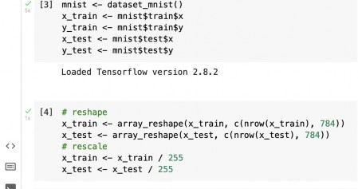

Note that green ticks will appear to the left of a code block once it has successfully run. Plots will appear beneath your executed code blocks.